# PA1_template

This assignment makes use of data from a personal activity monitoring device.

## 1. Load the data and show the top 6 rows:

```r
data = read.csv("activity 2.csv")
library(lubridate)
data$date <- ymd(data$date)
head(data)
```

```
##   steps       date interval
## 1    NA 2012-10-01        0
## 2    NA 2012-10-01        5
## 3    NA 2012-10-01       10
## 4    NA 2012-10-01       15
## 5    NA 2012-10-01       20
## 6    NA 2012-10-01       25
```

## 2. What is mean total number of steps taken per day?

Make a histogram of the total number of steps taken each day:

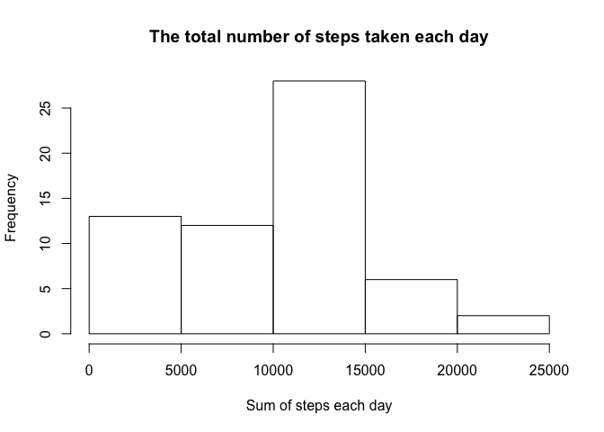

```r
sumdata = c()
sumdata$date = unique(data$date)
sumdata$steps = c()
sumdata = as.data.frame(sumdata)
for (i in 1: nrow(sumdata)) {
  sumdata[i, "steps"] = sum(data[data$date == sumdata[i, "date"], "steps"], na.rm = TRUE)
}
hist(sumdata$steps, xlab = "Sum of steps each day", main = "The total number of steps taken each day")
```

Calculate and report the mean and median total number of steps taken per day:

```r
mean_total = mean(sumdata$steps)
median_total = median(sumdata$steps)
```

The mean total number of steps taken per day is 9354.2295082, and the median total number of steps taken per day is 10395.

## 3. What is the average daily activity pattern?

Make a time series plot (i.e. type = “l”) of the 5-minute interval (x-axis) and the average number of steps taken, averaged across all days (y-axis)

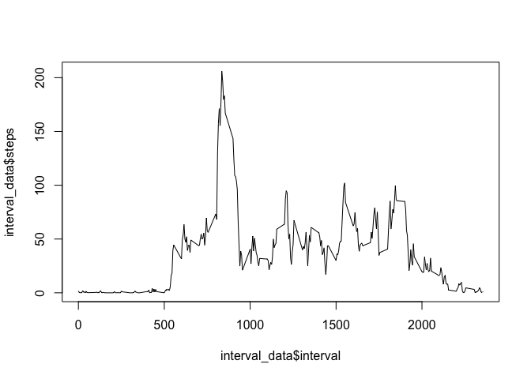

```r
interval_data = c()
interval_data$interval = unique(data$interval)
interval_data$steps = c()
interval_data = as.data.frame(interval_data)
for (i in 1: nrow(interval_data)) {
  interval_data[i, "steps"] = mean(data[data$interval == interval_data[i, "interval"], "steps"], na.rm = TRUE)
}
plot(interval_data$interval, interval_data$steps, type = "l")
```

Which 5-minute interval, on average across all the days in the dataset, contains the maximum number of steps?

```r
max_interval = interval_data[which.max(interval_data$steps),"interval"]
```

The 835 interval contains the maximum number of step.